# Migration on a network

# Introduction

Tigers have declined in numbers partly due to loss of habitat connectivity. Here, we use movement along a dynamic network to assess what habitat and connectivity characteristics facilitates or minimizes local extinctions.

## Simple network

- generate a simple network with 10 vertices fully connected.
- assign population sizes of animals to each vertex
- migration is possible through the network
- migration is dependent on population size
- add edge and vertex characteristics
  - Vertex can be vegetated, have food etc, have human habitaion
  - Edges can have weights associated with them due to roadways, forested networks, rivers/mountains, etc

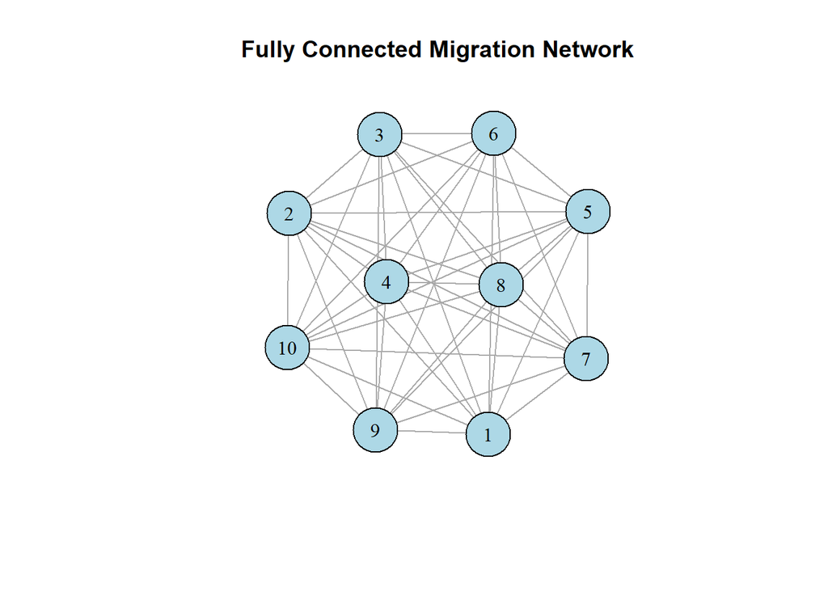

### Vertex characteristics

We assign population sizes $p_i$ at each vertex i, with habitat characteristics such as habitat type $t_i$, human presence (hunting, conflict) $h_i$, food availability $f_i$, climate $c_i$, etc. $p_i$ is evolving with birth, death (due to carrying capacity $K$, life time), and migration. If $p_i = 0$ for a long time, make $K=0$.

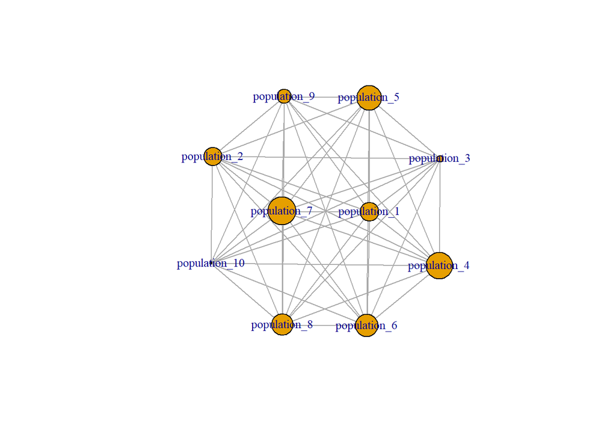

### Edge characteristics

We assign corridor types to edges, which can be wildlife corridor (for example - dense forest, open woodland, etc), terrain (river crossing, mountains, desert plateau), or urbanization (highways, human settlements). Each corridor type has a weight associated with it that affects migration.

Friction maps available for terrain. That can influence edge weight.

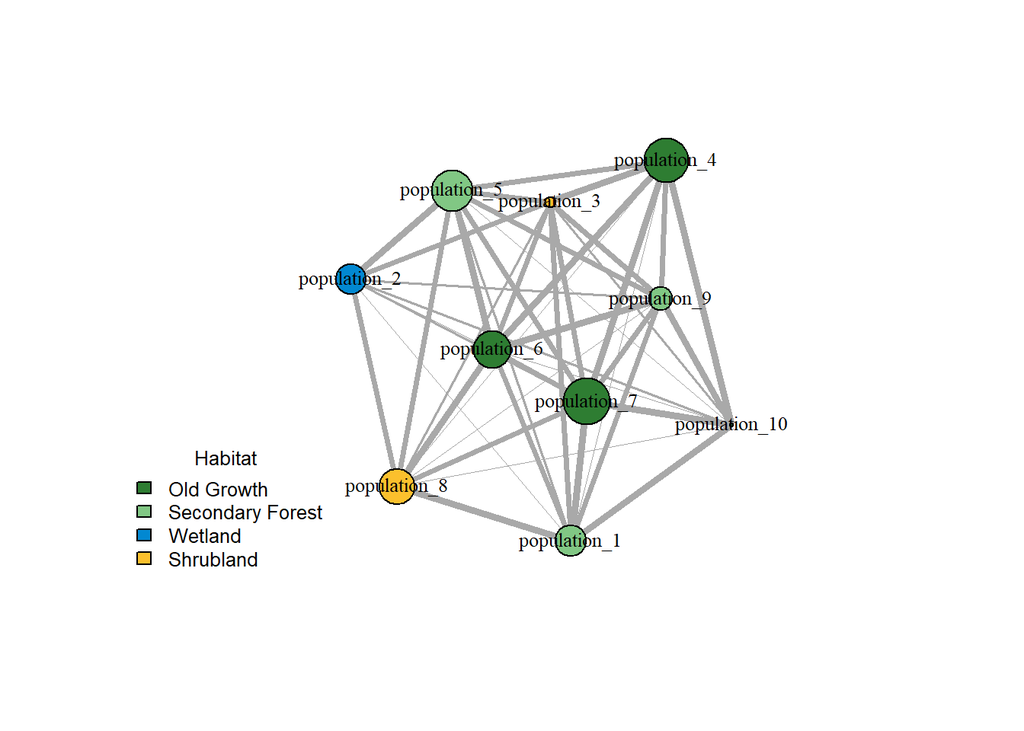

### Assign carrying capacity

Based on habitat type, food availability, and human presence.

|  | name | habitat | food_availability | human_presence | capacity | pop_size |
| --- | --- | --- | --- | --- | --- | --- |
| population_1 | population_1 | Secondary Forest | High | Low | 255 | 218 |
| population_2 | population_2 | Wetland | Medium | None | 405 | 403 |
| population_3 | population_3 | Shrubland | Low | High | 39 | 42 |
| population_4 | population_4 | Old Growth | Low | None | 450 | 440 |
| population_5 | population_5 | Secondary Forest | Medium | None | 270 | 276 |
| population_6 | population_6 | Old Growth | High | None | 600 | 494 |
| population_7 | population_7 | Old Growth | High | None | 600 | 540 |
| population_8 | population_8 | Shrubland | Medium | High | 47 | 43 |
| population_9 | population_9 | Secondary Forest | High | None | 300 | 326 |
| population_10 | population_10 | Old Growth | Medium | None | 540 | 584 |

### Migration, Birth, Death

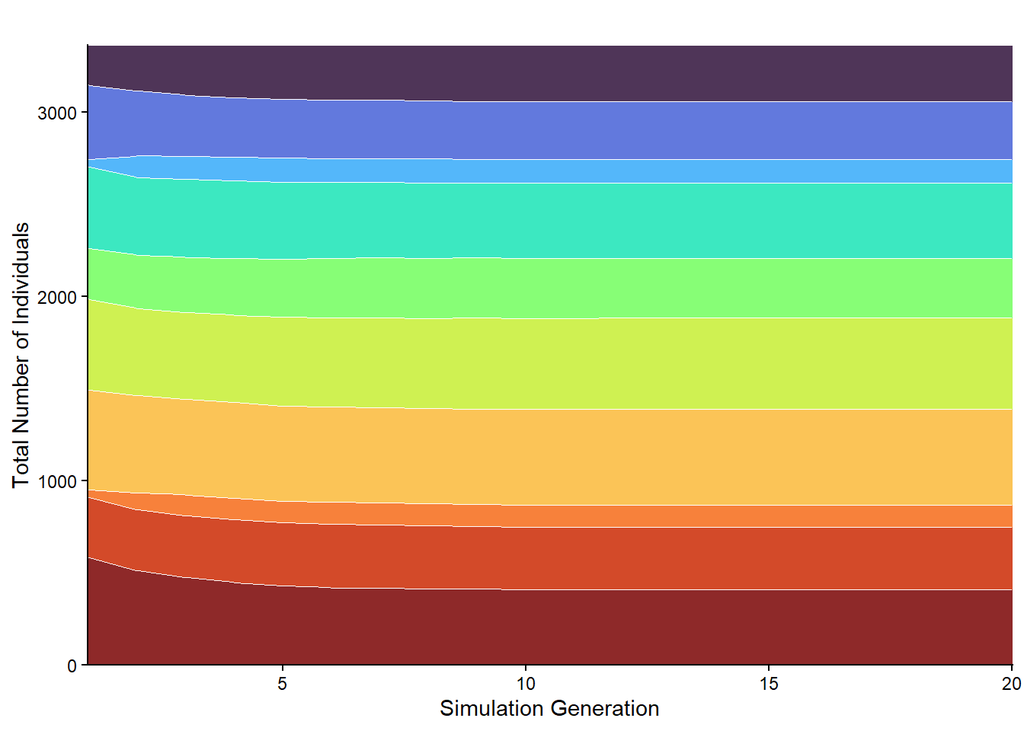

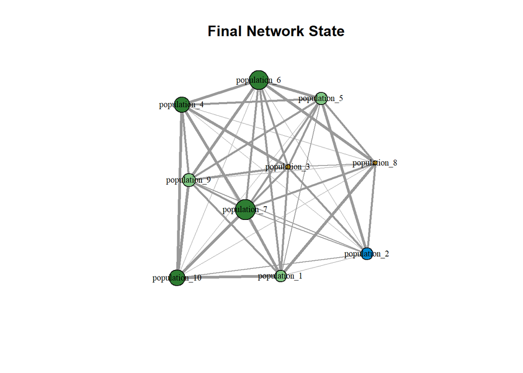